# Final_Project_STAT497

Denizcan Taşdelen

October 22, 2023

These data include information regarding `inflation` in Turkey between 2004 and 2021. Inflation data is only based on `The Consumer Price Index (CPI)` which is a measure of the average change in the prices over time paid by urban consumers for a market basket of consumer goods and services. In brief, a higher CPI indicates higher inflation.

```r
library("readxl")
#install.packages('forecast')
library(forecast)
library(stats)
library(ggplot2)
library(lattice)
library(gridExtra)
library(tseries)
library(TSA)
library(fUnitRoots)
library(caschrono)
library(pdR)
library(uroot)
library(fpp2)
#install.packages('hrbrthemes')
library(hrbrthemes)
#install.packages('gcookbook')
library(gcookbook)
library(tidyverse)
#install.packages('plotly', type='binary')
library(plotly)
########################
library(tidyverse)
#install.packages('tibbletime')
library(tibbletime)
library(anomalize)
#install.packages('anomalize')
#install.packages('tibbletime')
#install.packages('timetk')
library(timetk)
library(Rcpp)
library(wikipediatrend)
########################
library(timetk)
library(tidyverse)
library(tibbletime)
library(anomalize)
########################
#install.packages('anomalize')
########################
#install.packages("devtools")
#library(devtools)
########################
#install_github(devtools)
########################
#install.packages("wikipediatrend")
library(Rcpp)
library(wikipediatrend)
#install.packages("anomalize")
#install.packages("AnomalyDetection")
library(AnomalyDetection)
library(FinTS)
#install.packages("prophet")
library(prophet)
########################
remotes::install_github('https://github.com/twitter/AnomalyDetection')
```

```r
#data preparation
data <- read_excel("inflation.xlsx")

data1 <- data$Tarih
new1 <- as.Date(paste(data1,"-01",sep=""))
new1 <- data.frame(new1)

data2 <- data$`TP FG J0-3`

new2 <- data.frame(data2)

raw_data <- cbind(new1, new2)

colnames(raw_data) <- c('date', 'info')

mydata <- cbind(new1, new2)

colnames(mydata) <- c('date', 'info')

mydata <- mydata$info

my_new_data <- ts(mydata,start = 2004 , frequency = 12)

ts_data<-ts(raw_data$info,start=2004, frequency = 12)
```

**TIME SERIES PLOT AND INTERPRETATION**

Small inflation changes in time may also be indicating seasonality in the process.

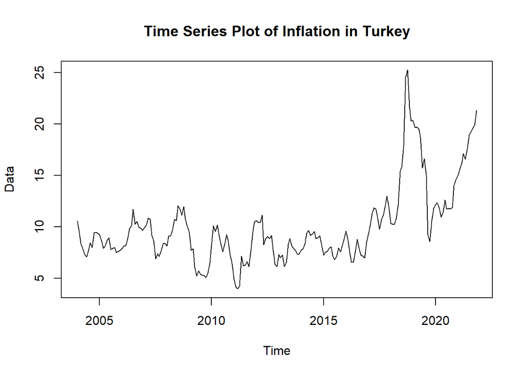

```r
plot(ts_data, main='Time Series Plot of Inflation in Turkey', xlab='Time', ylab='Data')
```

**ANOMALY DETECTION**

Firstly, we convert data to tibble class.

```r
raw_data <- raw_data

df <- as_tibble(raw_data)
class(df)
```

```
## [1] "tbl_df"     "tbl"        "data.frame"
```

Below graphs indicate that most of the outliers clustered around 2018, 2019 and beginnig of 2020.

Most of the anomalies gather around 2018 and 2019 where dramatical increase has been observed in inflation.

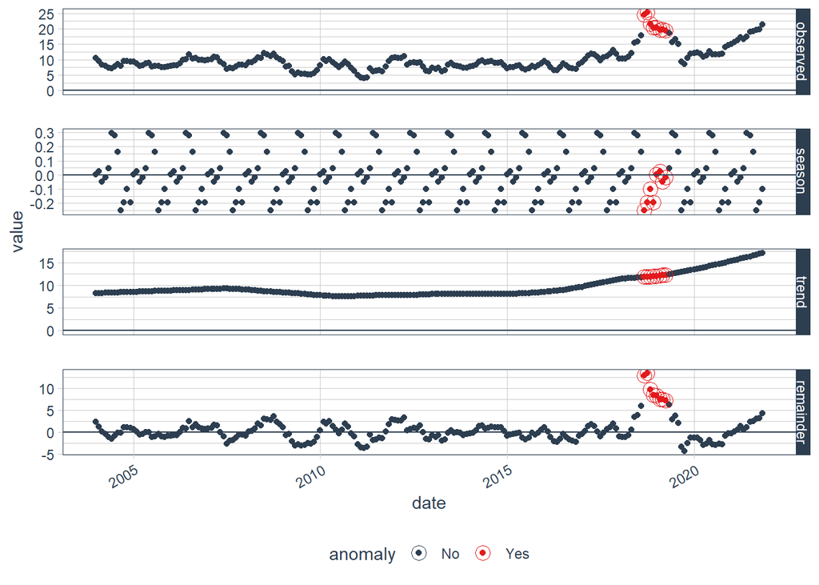

```r
df %>%
  time_decompose(info, method = "stl", frequency = "auto", trend = "auto") %>%
  anomalize(remainder, method = "gesd", alpha = 0.02, max_anoms = 0.2) %>%
  plot_anomaly_decomposition()
```

More detailed anomaly points can be seen in below graph by SH-ESD (Seasonal Hybrid ESD).

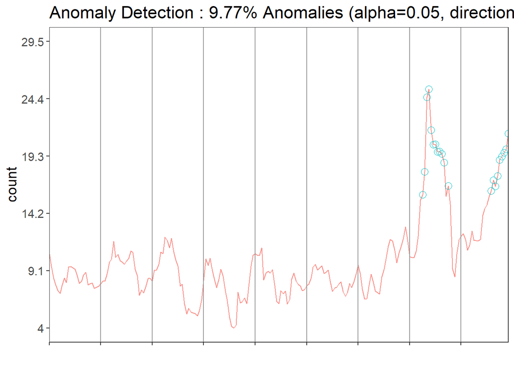

```r
a <- df %>%
  time_decompose(info) %>%
  anomalize(remainder) %>%
  time_recompose() %>%
  filter(anomaly == 'Yes')

AnomalyDetectionHiggins = AnomalyDetectionVec(raw_data$info, period=12, direction="pos", plot=TRUE, title = "Anomaly Detection")
AnomalyDetectionHiggins$plot
```

using tsclean function, anomalies was removed and replaced with interpolated values.

Time series plot after replacing anomalies with interpolated values can be seen from graph located below.

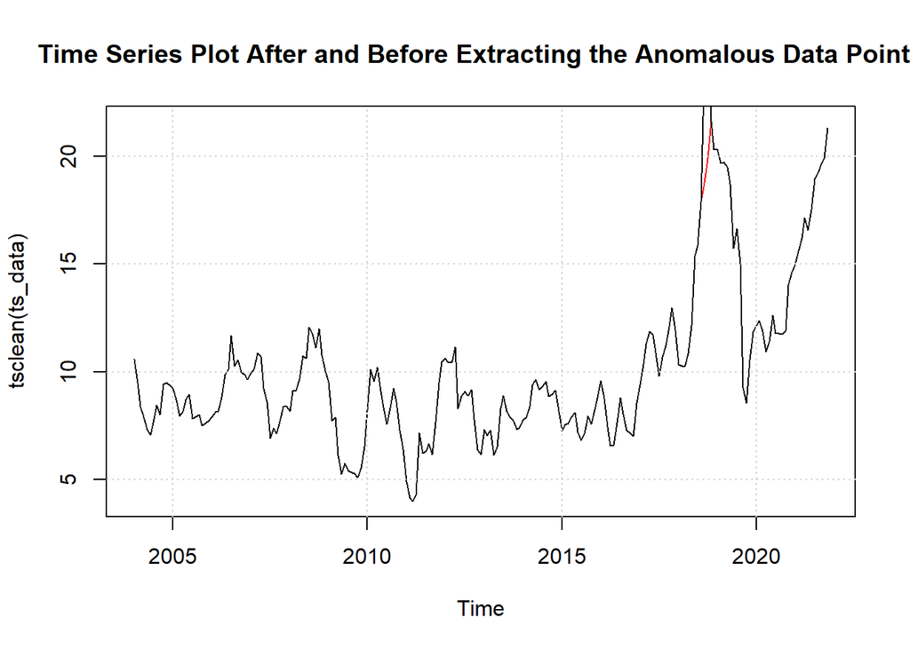

```r
plot(tsclean(ts_data), main="Time Series Plot After and Before Extracting the Anomalous Data Points", col='red')
lines(ts_data, col='black') #original dataset.
grid()
```

**Cross-Validation**

We keep last 12 observations out of the analysis since our data consists of monthly observations.

Train and Test sets can be seen below.

```r
ts_data <- tsclean(ts_data)
train_for_arıma <- window(ts_data, end=c(2020,11))
train_for_arıma
```

```
##            Jan       Feb       Mar       Apr       May       Jun       Jul
## 2004 10.594070  9.477294  8.397880  7.871632  7.307077  7.081502  7.795457
## 2005  9.235760  8.694827  7.944716  8.176630  8.700512  8.954389  7.816561
## 2006  7.930824  8.147760  8.161310  8.829888  9.863742 10.118997 11.692785
## 2007  9.929595 10.158269 10.863263 10.719962  9.227769  8.598305  6.899476
## 2008  8.171378  9.104237  9.152321  9.660518 10.740556 10.609206 12.064614
## 2009  9.500476  7.733136  7.885806  6.126055  5.236345  5.734257  5.392535
## 2010  8.185208 10.127845  9.560819 10.194265  9.099822  8.367509  7.577238
## 2011  4.900327  4.156521  3.986038  4.264607  7.172545  6.235879  6.311368
## 2012 10.613363 10.433317 10.427721 11.137950  8.280488  8.868567  9.065186
## 2013  7.307654  7.025404  7.290645  6.133784  6.514690  8.297519  8.884429
## 2014  7.751223  7.889047  8.385505  9.383390  9.656019  9.163472  9.319367
## 2015  7.240730  7.546687  7.610254  7.912801  8.092989  7.204528  6.814163
## 2016  9.578758  8.777355  7.459938  6.565403  6.582327  7.637471  8.793409
## 2017  9.218773 10.128289 11.291793 11.869619 11.722178 10.901085  9.788379
```

[output cut: 21 more lines]

```r
test_for_arıma  <- window(ts_data, start=c(2020, 12))
test_for_arıma
```

```
##           Jan      Feb      Mar      Apr      May      Jun      Jul      Aug
## 2020
## 2021 14.97368 15.61091 16.19024 17.14015 16.59285 17.52533 18.95168 19.25266
##           Sep      Oct      Nov      Dec
## 2020                            14.59932
## 2021 19.58257 19.89002 21.31253
```

**BOX-COX TRANSFORMATION**

Variance seems to be low.

```r
sd(train_for_arıma)
```

```
## [1] 3.147913
```

We apply BoxCox transformation on the train data set.

```r
lambda <- BoxCox.lambda(train_for_arıma)

train_for_arıma <- BoxCox(train_for_arıma, lambda)
#transformed_data <- log(ts_data)  #log transformation alınca fit4'te Arima(train, order = c(0, 1, 1), seasonal = c(0, 0, 1)) significant çıkıyo.
```

It can be seen by the below graph that we catched the stability in variance.

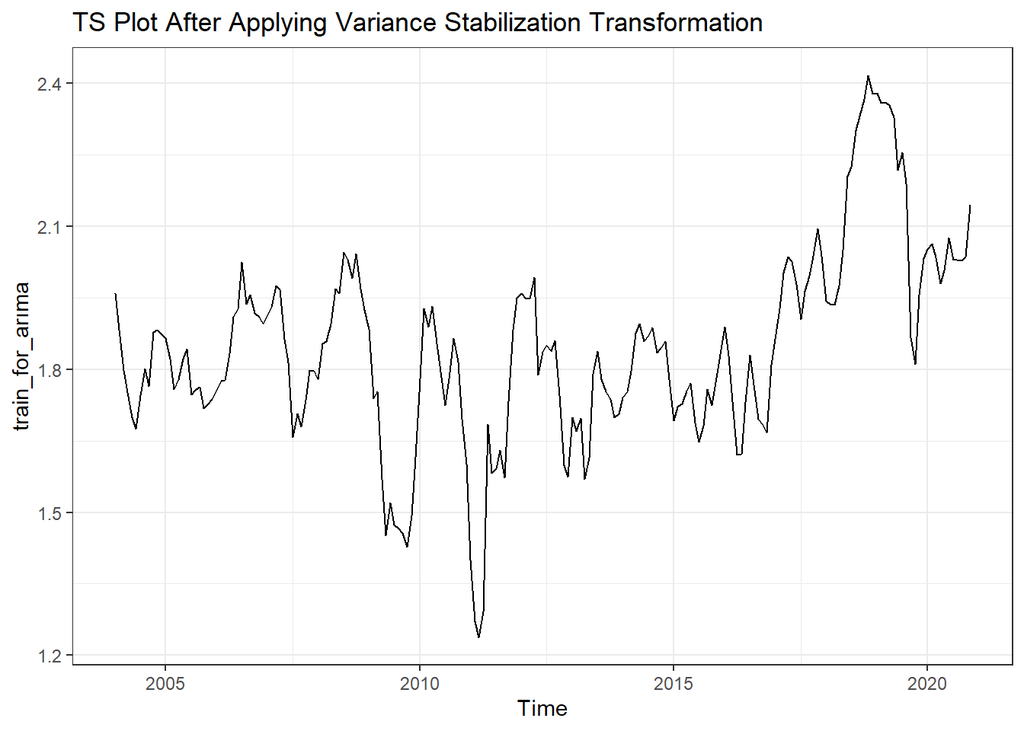

```r
autoplot(train_for_arıma, main='TS Plot After Applying Variance Stabilization Transformation') + theme_bw()
```

```r
#DO WE APPLY TRANSFORMATION AFTER OR BEFORE DIAGNOSTIC CHECK????????????
#raw_data <- raw_data[1:203, ]
#raw_data$info <-BoxCox(raw_data$info, lambda)
#tail(train_for_arıma)
```

ACF and PACF plots shows that there is slow decay in ACF indicating nonstationary process.

We cannot comment on PACF.

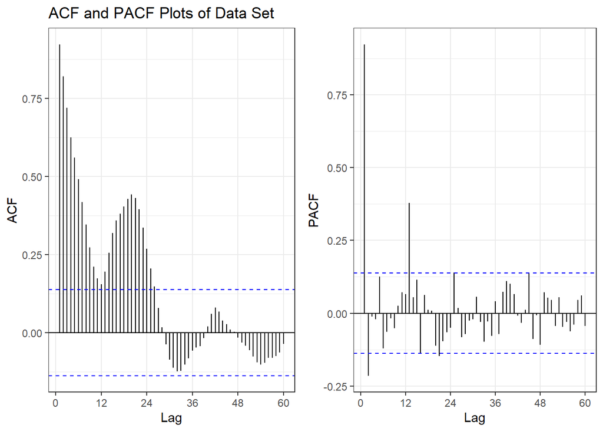

```r
tt3 <- ggAcf(train_for_arıma, lag.max = 60, main='ACF and PACF Plots of Data Set') + theme_bw()
tt4 <- ggPacf(train_for_arıma, main='', lag.max = 60) + theme_bw()
grid.arrange(tt3, tt4, nrow=1)
```

**KPSS, PP, ADF, HEGY AND CANOVA-HENSEN TESTS**

KPSS Test indicates that we have a nonstationary process. (p-value < 0.05)

```r
#non stat
kpss.test(train_for_arıma, null=c('Level'))
```

```
##
##  KPSS Test for Level Stationarity
##
## data:  train_for_arıma
## KPSS Level = 1.1085, Truncation lag parameter = 4, p-value = 0.01
```

KPSS with trend indicates stochastic trend. (p-value < 0.05)

```r
#stochastic
kpss.test(train_for_arıma, null=c('Trend'))
```

```
##
##  KPSS Test for Trend Stationarity
##
## data:  train_for_arıma
## KPSS Trend = 0.42737, Truncation lag parameter = 4, p-value = 0.01
```

PP Test yields result as stationary. (p-value < 0.05)

```r
#stat
pp.test(train_for_arıma)
```

```
##
##  Phillips-Perron Unit Root Test
##
## data:  train_for_arıma
## Dickey-Fuller Z(alpha) = -23.841, Truncation lag parameter = 4, p-value
## = 0.02749
## alternative hypothesis: stationary
```

Below code chunk shows that mean is different than zero. (type = ‘c’ in below ADF test)

```r
mean(train_for_arıma)
```

```
## [1] 1.846476
```

Also, PACF cuts off after lag 2. (lags = 2 in below ADF test)

ADF test gives result as stationary.

So, we do not apply ADF test with ‘ct’.

```r
adfTest(train_for_arıma, lags = 2, type = 'c')
```

```
##
## Title:
##  Augmented Dickey-Fuller Test
##
## Test Results:
##   PARAMETER:
##     Lag Order: 2
##   STATISTIC:
##     Dickey-Fuller: -3.1388
##   P VALUE:
##     0.02601
##
## Description:
##  Sun Jan 22 22:57:58 2023 by user: Educatıon
```

canova-hensen test for seasonal unit root

#H0 : The series is purely deterministic and stationary.

#H1 : We have stochastic seasonality.

```r
library(uroot)
ch.test(train_for_arıma, type = "dummy",sid=c(1:12)) #since we have monthly data, we use sid=c(1:12)
```

```
##
##  Canova and Hansen test for seasonal stability
##
## data:  train_for_arıma
##
##      statistic pvalue
## [1,]    1.1288 0.6253
## ---
## Signif. codes: 0 '***' 0.001 '**' 0.01 '*' 0.05 '.' 0.1 ' ' 1
##
## Test type: seasonal dummies
## NW covariance matrix lag order: 14
## First order lag: no
## Other regressors: no
## P-values: interpolation in original tables
```

Below HEGY test yields that there is regular unit root problem in the data.

```r
#regular unit root
HEGY.test(wts = train_for_arıma, itsd = c(1, 1, 0), regvar = 0, selectlags = list(mode = 'signf', Pmax=NULL))$stats
```

```
##               Stat. p-value
## tpi_1     -1.597689    0.10
## tpi_2     -6.783505    0.01
## Fpi_3:4   38.298480    0.01
## Fpi_5:6   35.687251    0.01
## Fpi_7:8   27.962372    0.01
## Fpi_9:10  40.392344    0.01
## Fpi_11:12 42.012043    0.01
## Fpi_2:12  18.036425      NA
## Fpi_1:12  18.226417      NA
```

Canova-Hensen, PP and ADF tests give result as stationary.

But, there is slow decay in ACF and also HEGY test indicate regular unit root problem.

KPSS test shows that have a nonstationary series with stochastic trend.

Hence, we continue to the analysis as we have a nonstationary process.

**Removing Trend From Stochastic Trend by Taking Differencing**

Below graph shows after taking first regular differencing,

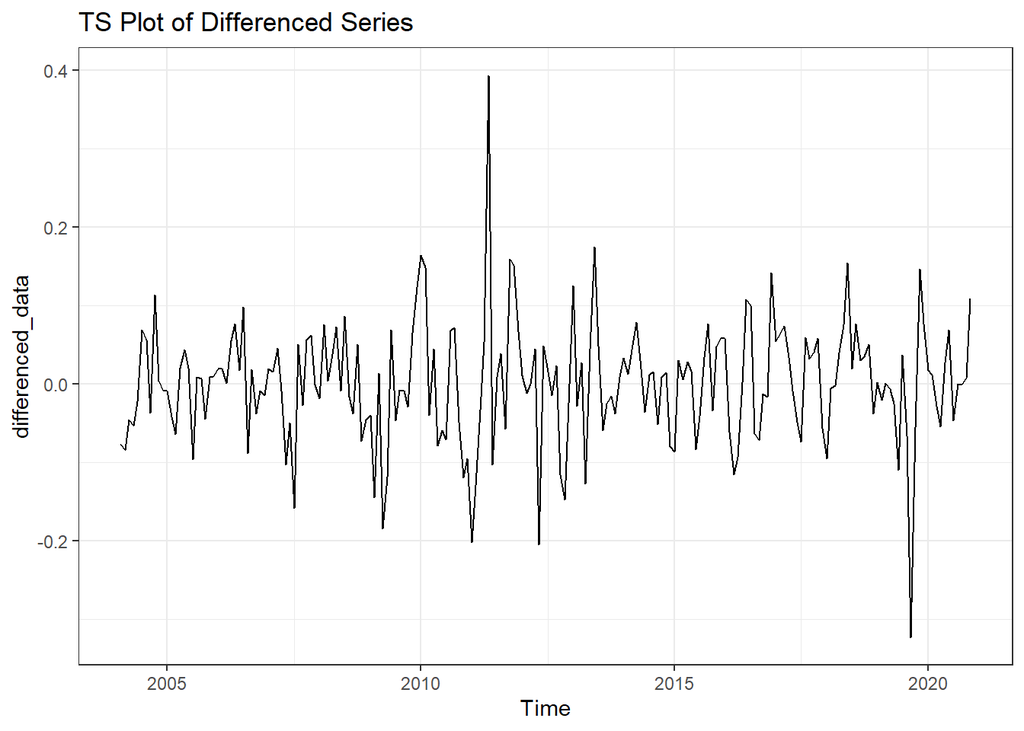

```r
differenced_data <- diff(train_for_arıma)
autoplot(differenced_data, main="TS Plot of Differenced Series") + theme_bw()
```

KPSS test indicates stationary process. (p-value > 0.05)

```r
#stat
kpss.test(differenced_data, null=c('Level'))
```

```
##
##  KPSS Test for Level Stationarity
##
## data:  differenced_data
## KPSS Level = 0.052908, Truncation lag parameter = 4, p-value = 0.1
```

Mean is around zero. (type = ‘nc’)

```r
mean(differenced_data)
```

```
## [1] 0.000923941
```

ADF test indicates stationary process. (p-value < 0.05)

```r
#stat
adfTest(differenced_data, type = 'nc')
```

```
##
## Title:
##  Augmented Dickey-Fuller Test
##
## Test Results:
##   PARAMETER:
##     Lag Order: 1
##   STATISTIC:
##     Dickey-Fuller: -9.3416
##   P VALUE:
##     0.01
##
## Description:
##  Sun Jan 22 22:57:59 2023 by user: Educatıon
```

PP test indicates stationary process. (p-value < 0.05)

```r
#stat
pp.test(differenced_data)
```

```
##
##  Phillips-Perron Unit Root Test
##
## data:  differenced_data
## Dickey-Fuller Z(alpha) = -144.76, Truncation lag parameter = 4, p-value
## = 0.01
## alternative hypothesis: stationary
```

HEGY test indicates that after taking first regular differencing, unit root problem disappears.

```r
#unit root disappears
HEGY.test(wts = differenced_data, itsd = c(0, 0, 0), regvar = 0, selectlags = list(mode = 'signf', Pmax=NULL))$stats
```

```
##               Stat. p-value
## tpi_1     -6.418555    0.01
## tpi_2     -5.402908    0.01
## Fpi_3:4   23.421628    0.01
## Fpi_5:6   38.922171    0.01
## Fpi_7:8   31.496115    0.01
## Fpi_9:10  43.852183    0.01
## Fpi_11:12 45.134485    0.01
## Fpi_2:12  19.886412      NA
## Fpi_1:12  20.314463      NA
```

**IDENTIFYING A PROPER ARIMA/SARIMA MODEL**

ACF, PACF plots after taking regular differencing:

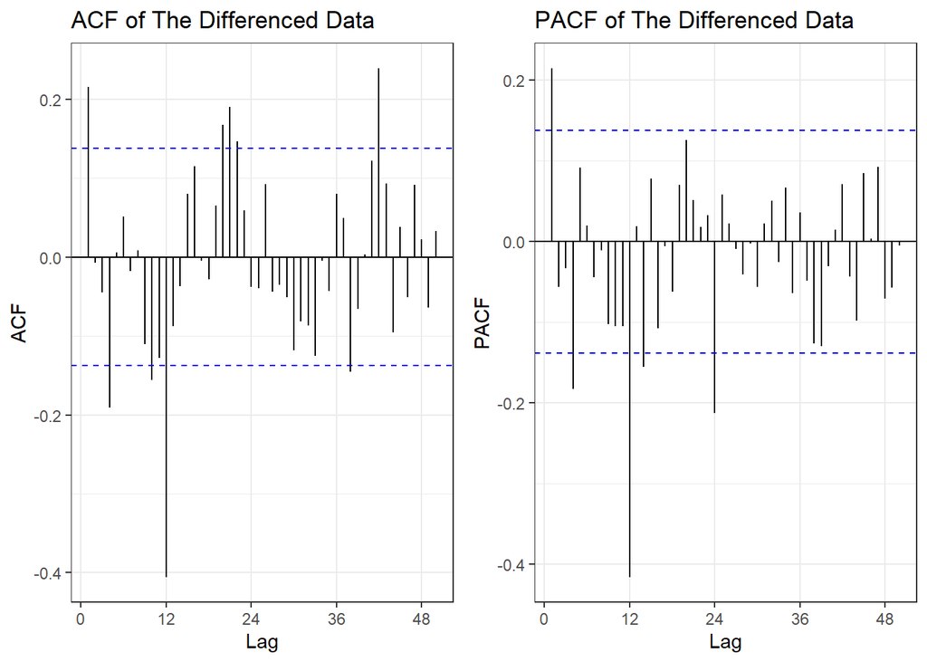

```r
p3 <- ggAcf(differenced_data, lag.max = 50, main='ACF of The Differenced Data') + theme_bw()
p4 <- ggPacf(differenced_data, lag.max = 50, main='PACF of The Differenced Data') + theme_bw()
grid.arrange(p3, p4, nrow=1)
```

Cosidering significant lags, we can suggest below models to the data:

`suggest_1: SARIMA(4, 1, 4)(2, 0, 1)12`

`suggest_2: SARIMA(1, 1, 1)(2, 0, 1)12`

`suggest_3: SARIMA(4, 1, 1)(2, 0, 1)12`

`suggest_4: SARIMA(1, 1, 4)(2, 0, 1)12`

**ESTIMATING THE PARAMETERS**

**1) Nonsignificant model:**

There are many NaN which hinder making estimation.

```r
fit1<-Arima(train_for_arıma, order = c(4,1 ,4), seasonal = c(2, 0, 1))
fit1
```

```
## Series: train_for_arıma
## ARIMA(4,1,4)(2,0,1)[12]
##
## Coefficients:
##           ar1     ar2      ar3      ar4     ma1      ma2     ma3     ma4
##       -0.5132  0.1313  -0.6219  -0.4405  0.7524  -0.1274  0.4860  0.4474
## s.e.      NaN     NaN   0.1609      NaN     NaN   0.5931  0.3189     NaN
##          sar1     sar2     sma1
##       -0.2524  -0.1306  -0.3365
## s.e.   0.2832   0.1519   0.2962
##
## sigma^2 = 0.004337:  log likelihood = 266.04
## AIC=-508.08   AICc=-506.43   BIC=-468.39
```

**2) Nonsignificant model:**

sar1 is nonsignificant.

```r
fitd1<-Arima(train_for_arıma, order = c(4,1 ,4), seasonal = c(1, 0, 1))
fitd1
```

```
## Series: train_for_arıma
## ARIMA(4,1,4)(1,0,1)[12]
##
## Coefficients:
##          ar1      ar2     ar3     ar4      ma1     ma2     ma3      ma4
##       0.8143  -0.7173  0.0290  0.3078  -0.6142  0.4311  0.2447  -0.6123
## s.e.  0.2137   0.2755  0.2692  0.2157   0.1850  0.2240  0.2209   0.1905
##          sar1     sma1
##       -0.1370  -0.4804
## s.e.   0.1336   0.1237
##
## sigma^2 = 0.004117:  log likelihood = 268.96
## AIC=-515.92   AICc=-514.53   BIC=-479.53
```

ar4, ma4, sma1 are significant.

```r
significant1<-Arima(train_for_arıma, order = c(4,1 ,4), seasonal = c(0, 0, 1))
significant1
```

```
## Series: train_for_arıma
## ARIMA(4,1,4)(0,0,1)[12]
##
## Coefficients:
##          ar1      ar2      ar3     ar4      ma1     ma2     ma3      ma4
##       0.7929  -0.6083  -0.0505  0.4069  -0.6028  0.3465  0.2992  -0.6895
## s.e.  0.2024   0.2868   0.2811  0.2046   0.1645  0.2226  0.2195   0.1708
##          sma1
##       -0.5756
## s.e.   0.0686
##
## sigma^2 = 0.004116:  log likelihood = 268.43
## AIC=-516.87   AICc=-515.72   BIC=-483.78
```

**4) Nonsignificant model:**

```r
significant2<-Arima(train_for_arıma, order = c(2,1 ,1), seasonal = c(0, 0, 1))
significant2
```

```
## Series: train_for_arıma
## ARIMA(2,1,1)(0,0,1)[12]
##
## Coefficients:
##          ar1      ar2      ma1     sma1
##       0.8000  -0.2582  -0.5975  -0.5647
## s.e.  0.5569   0.0776   0.5826   0.0719
##
## sigma^2 = 0.004352:  log likelihood = 262.17
## AIC=-514.35   AICc=-514.04   BIC=-497.8
```

**5) Significant model:**

ar1, ma1, sma1 are significant.

```r
significant3<-Arima(train_for_arıma, order = c(1,1 ,1), seasonal = c(0, 0, 1))
significant3
```

```
## Series: train_for_arıma
## ARIMA(1,1,1)(0,0,1)[12]
##
## Coefficients:
##           ar1     ma1     sma1
##       -0.5604  0.7852  -0.5648
## s.e.   0.2013  0.1570   0.0654
##
## sigma^2 = 0.004312:  log likelihood = 262.54
## AIC=-517.08   AICc=-516.88   BIC=-503.85
```

**6) Nonsignificant model:**

ma4, sma1 are significant.

ar4, sar1 are nonsignificant.

```r
fit2<-Arima(train_for_arıma ,order = c(4, 1, 4), seasonal = c(1, 0, 1))
fit2
```

```
## Series: train_for_arıma
## ARIMA(4,1,4)(1,0,1)[12]
##
## Coefficients:
##          ar1      ar2     ar3     ar4      ma1     ma2     ma3      ma4
##       0.8143  -0.7173  0.0290  0.3078  -0.6142  0.4311  0.2447  -0.6123
## s.e.  0.2137   0.2755  0.2692  0.2157   0.1850  0.2240  0.2209   0.1905
##          sar1     sma1
##       -0.1370  -0.4804
## s.e.   0.1336   0.1237
##
## sigma^2 = 0.004117:  log likelihood = 268.96
## AIC=-515.92   AICc=-514.53   BIC=-479.53
```

Among significant models 3 and 5, model 5 has the lowest BIC value as -503.85.

Hence, we can choose model 5, (SARIMA(1,1,1)(0,0,1)[12]), as the best one.

```r
#I used fit4 in the upcoming code chunks as the name. So, I changed of the name of the significant model as fit4.
fit4<-significant3
```

**DIAGNISTIC CHECKING**

**Evaluating Residuals**

Below ACF, PACF plot of the residuls show that most of the lags are inside the White Noise bands.

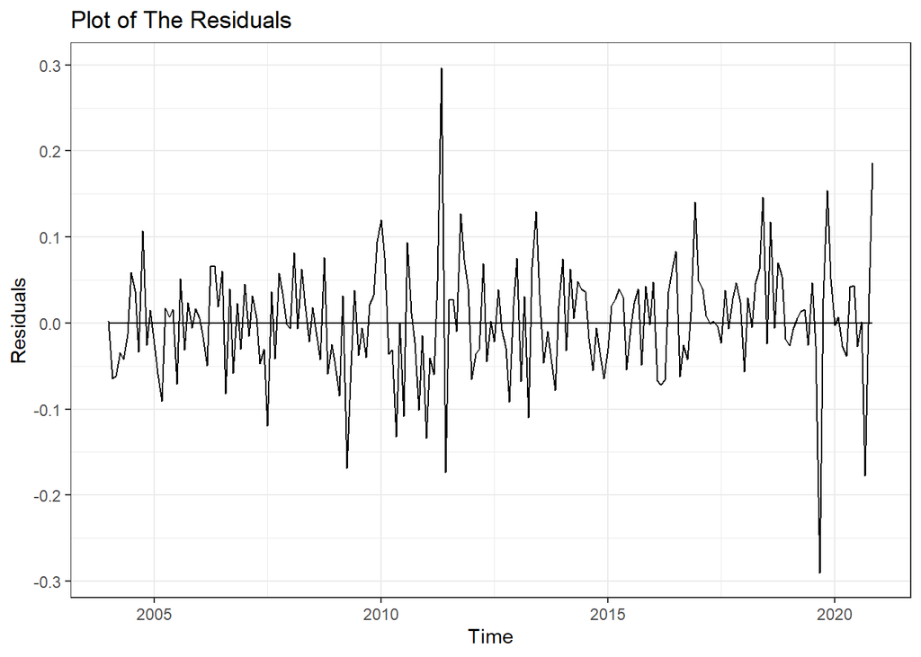

```r
r <- resid(fit4)

autoplot(r)+geom_line(y=0)+theme_bw()+ggtitle("Plot of The Residuals") +
  labs(x = "Time", y = "Residuals")
```

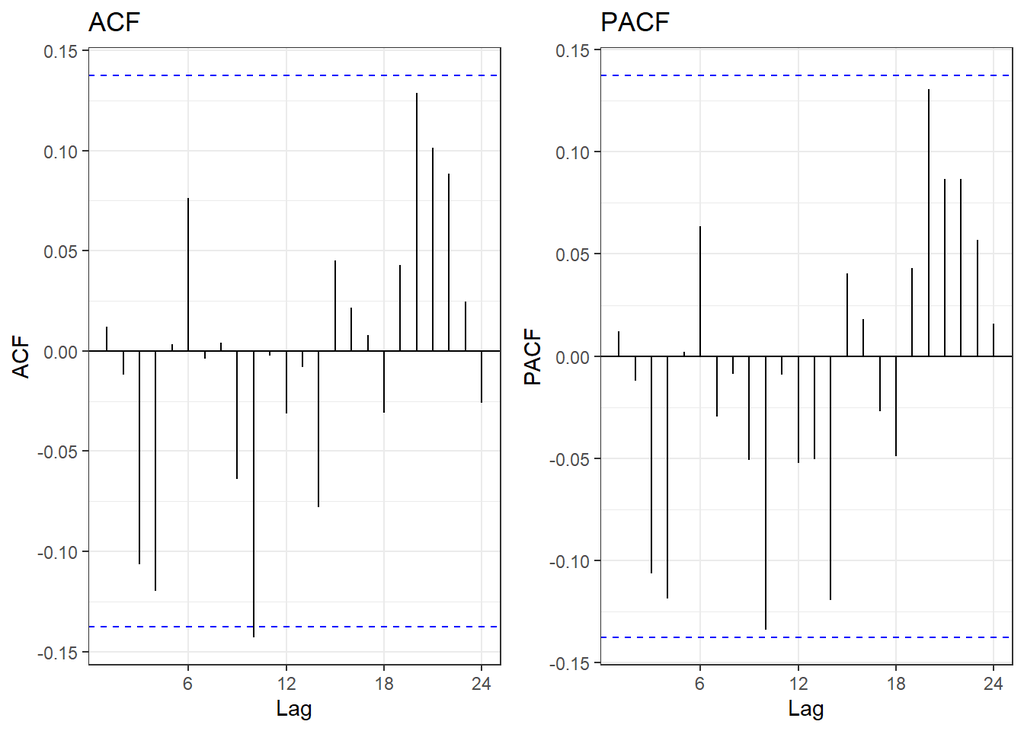

```r
k3 <- ggAcf(r, main='ACF') + theme_bw()
k4 <- ggPacf(r, main='PACF') + theme_bw()
grid.arrange(k3, k4, nrow=1)
```

Below QQ Plot shows that most of the residuals of the model lie on 45 degree straight line indicating that residuals are normally distributed.

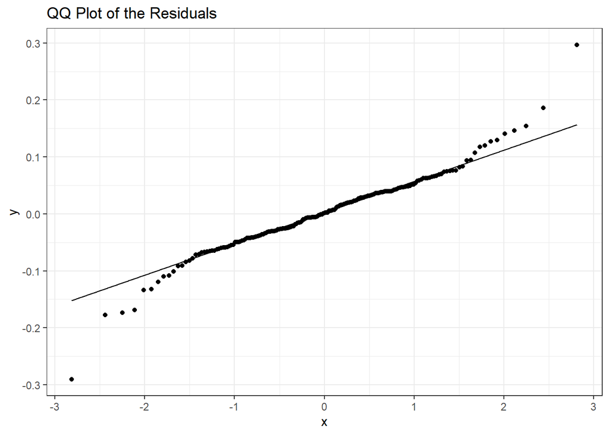

```r
ggplot(r, aes(sample = r)) +stat_qq()+geom_qq_line()+ggtitle("QQ Plot of the Residuals")+theme_bw()
```

The following histogram is the histogram of the residuals with normal curve.

Histogram of the resiudals shows that they might have a symmetric distribution.

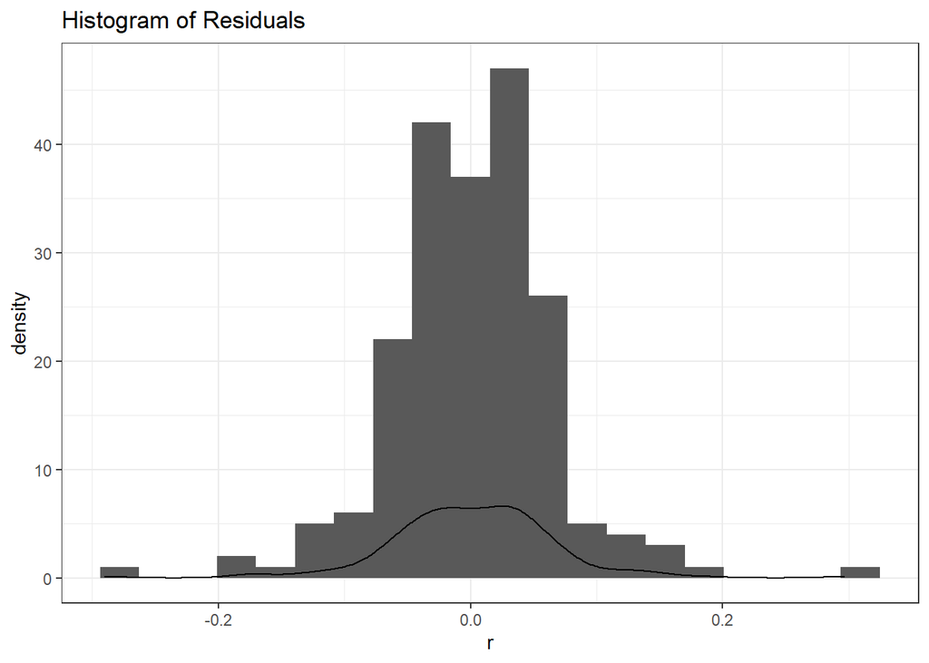

```r
ggplot(r,aes(x=r))+geom_histogram(bins=20)+geom_density()+ggtitle("Histogram of Residuals")+theme_bw()
```

**Formal Normality Tests (Jarque Bera and Shapiro-Wilk test)**

For both tests, the following hypothesis are used:

Ho: Residuals have normal distribution.

H1: Residuals don’t have normal distribution.

Both of the tests indicate that residuals are not normally distributed. (p-values < 0.05)

```r
jarque.bera.test(r)
```

```
##
##  Jarque Bera Test
##
## data:  r
## X-squared = 108.65, df = 2, p-value < 2.2e-16
```

```r
shapiro.test(r)
```

```
##
##  Shapiro-Wilk normality test
##
## data:  r
## W = 0.95608, p-value = 6.548e-06
```

**Testing Serial Correlation in Residuals**

In the ACF, almost all spikes are in the WN band which shows that there is no serial correlation in the residuals.

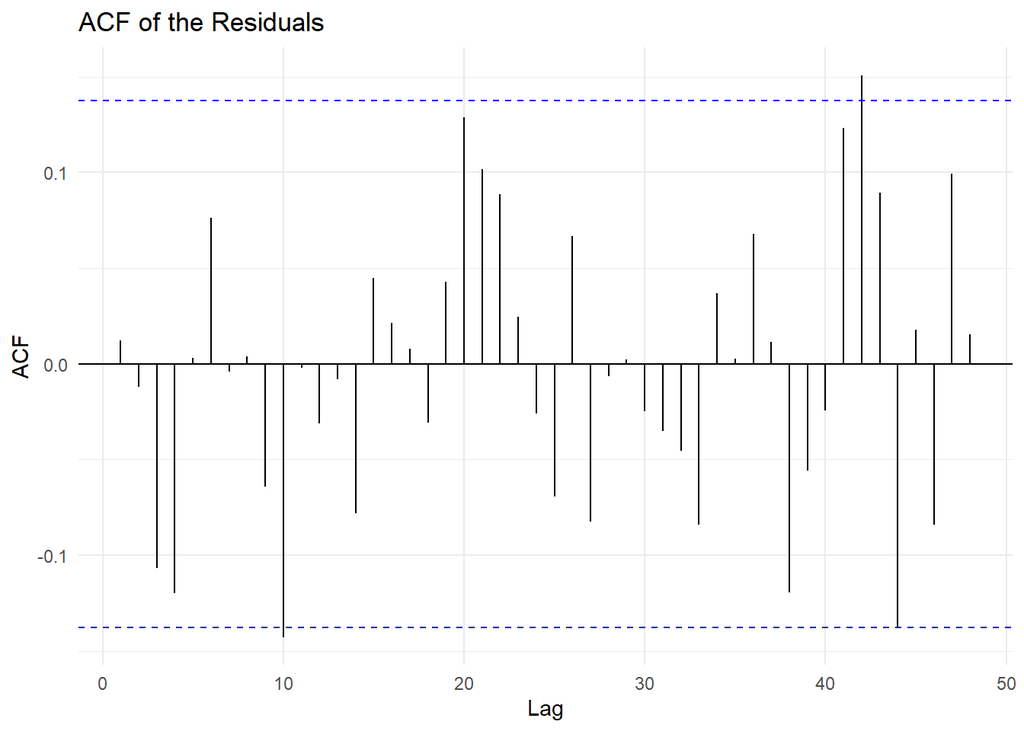

```r
ggAcf(as.vector(r),main="ACF of the Residuals",lag = 48)+theme_minimal()
```

To be sure, let us apply formal tests:

#There are three tests used for detecting serial correlation among residuals. #For all tests, we have the following hypothesis.

#H0: there is no serial correlation of any order up to p p1=….=pp=0

#H1: there is a serial correlation up to p / ρi≠0

**Breusch-Godfrey Test**

Since p value is greater than alpha, we have 95% confident that the residuals of the model are uncorrelated, according to results of Breusch-Godfrey Test.

```r
m <- lm(r ~ 1+zlag(r))
library(lmtest)
bgtest(m,order=12)
```

```
##
##  Breusch-Godfrey test for serial correlation of order up to 12
##
## data:  m
## LM test = 12.555, df = 12, p-value = 0.4022
```

**Box-Ljung Test**

Since p value is greater than alpha, residuals of the model are `uncorrelated` according to results of `Box-Ljung Test`.

```r
Box.test(r,lag=12,type = c("Ljung-Box"))
```

```
##
##  Box-Ljung test
##
## data:  r
## X-squared = 12.14, df = 12, p-value = 0.4345
```

**Box-Pierce Test**

Since p value is greater than alpha, residuals of the model are `uncorrelated` according to results of `Box-Pierce Test`.

```r
Box.test(r,lag=12,type = c("Box-Pierce"))
```

```
##
##  Box-Pierce test
##
## data:  r
## X-squared = 11.627, df = 12, p-value = 0.4761
```

**HETEROSCEDASTICITY TESTS**

Most of the spikes are in the white noise band in both plots, So, it can be said that there is no heteroscedasticity problem.

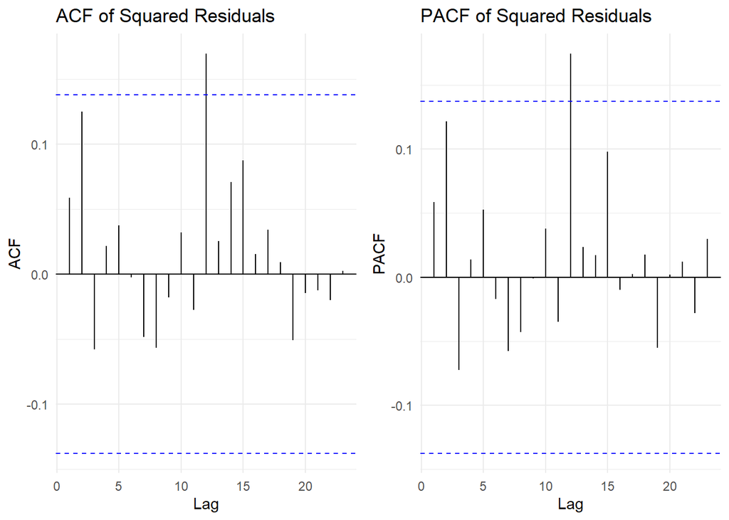

```r
rr=r^2
g1<-ggAcf(as.vector(rr))+theme_minimal()+ggtitle("ACF of Squared Residuals")
g2<-ggPacf(as.vector(rr))+theme_minimal()+ggtitle("PACF of Squared Residuals")
grid.arrange(g1,g2,ncol=2)
```

Since ARCH Engle’s Test yields p-value > 0.05, it can be concluded that there is no Heteroscedasticity problem.

```r
ArchTest(r)
```

```
##
##  ARCH LM-test; Null hypothesis: no ARCH effects
##
## data:  r
## Chi-squared = 13.403, df = 12, p-value = 0.3405
```

**Breusch-Pagan Test For Heteroscedasticity**

H0: Residuals are homoscedastic. (The variance is constant.)

H1: Residuals are heteroscedastic. (The variance is changing over time.)

Since p value is greater than alpha, we fail reject Ho. Therefore, we can say that we have enough evidence to claim that there is no heteroscedasticity problem, according to results of Breusch-Pagan test.

```r
library(lmtest)
m = lm(r ~ train_for_arıma+zlag(train_for_arıma)+zlag(train_for_arıma,1))
bptest(m)
```

```
##
##  studentized Breusch-Pagan test
##
## data:  m
## BP = 3.0505, df = 2, p-value = 0.2176
```

**FORECASTING**

**a. Forecasting With SARIMA**

As it is seen, although fitted line is suitable for most of the points in the train set, SARIMA model fails to catch the last increase in inflation. It can be concluded that the SARIMA model is prone to follow mean of the process and the prediction line folds towards the midpoint of the graph.

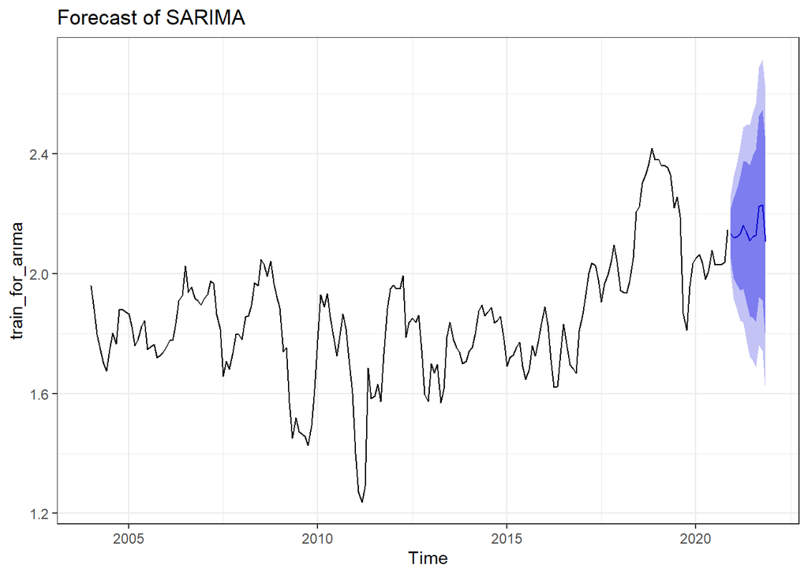

```r
f<-forecast(fit4, h=12)
autoplot(f)+theme_bw()+ggtitle("Forecast of SARIMA")
```

**Checking The Performance of The SARIMA Model**

```r
f_t<-exp(f$mean)
accuracy(f_t, test_for_arıma)
```

```
##                ME     RMSE      MAE     MPE    MAPE      ACF1 Theil's U
## Test set 9.095204 9.306072 9.095204 50.9903 50.9903 0.6140084  11.55985
```

**b. Forecasting With ETS**

TBATS, PROPHET, NNETAR and ETS require NOT transformed data.

Below sets are train and test sets that are NOT transformed.

```r
train <- window(ts_data, end=c(2020,11))
test  <- window(ts_data, start=c(2020, 12))
```

Below graphs show forecasts done by some of the best fitted models by ETS.

Forecast done by ETS model does not differ too much from that of SARIMA model. Fitted line is appropriate for the train data, but the last increase could not catched by ETS, too.

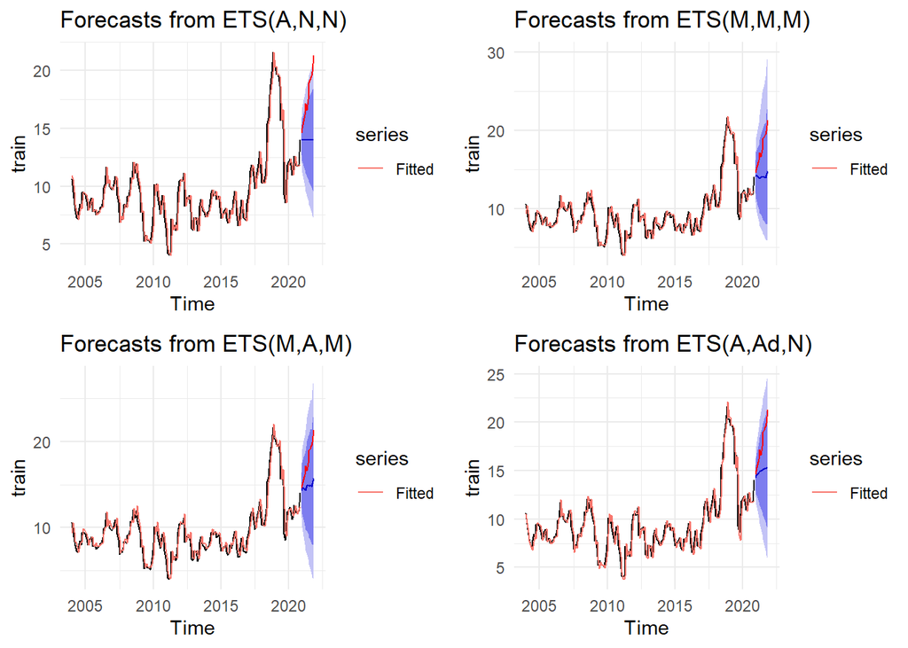

```r
fit1 <- ets(train, model = "ZZZ")
ets1 <- forecast(fit1, h = 12)
fit2 <- ets(train, model = "MMM")
ets2 <- forecast(fit2, h = 12)
fit3 <- ets(train, model = "MAM")
ets3 <- forecast(fit3, h = 12)
best_ets <- ets(train, model = "AAN")#======>>>> BEST ETS model
ets4 <- forecast(best_ets, h = 12)
a1 <- autoplot(ets1)+autolayer(test,series="actual",color="red")+autolayer(fitted(ets1), series="Fitted")+theme_minimal()
a2 <- autoplot(ets2)+autolayer(test,series="actual",color="red")+autolayer(fitted(ets2), series="Fitted")+theme_minimal()
a3 <- autoplot(ets3)+autolayer(test,series="actual",color="red")+autolayer(fitted(ets3), series="Fitted")+theme_minimal()
a4 <- autoplot(ets4)+autolayer(test,series="actual",color="red")+autolayer(fitted(ets4), series="Fitted")+theme_minimal()
grid.arrange(a1, a2, a3, a4, nrow=2)
```

The best exponential smoothing model using ets function can be seen below:

It is seen that we have exponential smoothing model having `additive error` and `additive trend`.

```r
best_ets
```

```
## ETS(A,Ad,N)
##
## Call:
##  ets(y = train, model = "AAN")
##
##   Smoothing parameters:
##     alpha = 0.9986
##     beta  = 0.1541
##     phi   = 0.8
##
##   Initial states:
##     l = 11.7687
##     b = -1.5272
##
##   sigma:  1.0087
##
##      AIC     AICc      BIC
## 1089.030 1089.458 1108.909
```

**Checking The Performance of The ETS Model**

According to below table, since RMSE value is the smallest one among all models for the model = “AAN”, we can choose it as a best forecast model done by ETS.

```r
rmse_ets_train_1 <- accuracy(ets1, test)[1, 2]  #RMSE FOR TRAİN
rmse_ets_train_2 <- accuracy(ets2, test)[1, 2]  #RMSE FOR TRAİN
rmse_ets_train_3 <- accuracy(ets3, test)[1, 2]  #RMSE FOR TRAİN
rmse_ets_train_4 <- accuracy(ets4, test)[1, 2]  #RMSE FOR TRAİN

rmse_ets_test_1 <- accuracy(ets1, test)[2, 2]  #RMSE FOR TEST
rmse_ets_test_2 <- accuracy(ets2, test)[2, 2]  #RMSE FOR TEST
rmse_ets_test_3 <- accuracy(ets3, test)[2, 2]  #RMSE FOR TEST
rmse_ets_test_4 <- accuracy(ets4, test)[2, 2]  #RMSE FOR TEST

#ets with 'AAN' seems to be the best choice since it has the lowest RMSE values for train and test.
matrix(c(rmse_ets_train_1, rmse_ets_test_1,
         rmse_ets_train_2, rmse_ets_test_2,
         rmse_ets_train_3, rmse_ets_test_3,
         rmse_ets_train_4, rmse_ets_test_4), nrow=2, ncol=4,
       dimnames = list(c('rmse_train', 'rmse_test'), c('MNM', 'MMM', 'MAM', 'AAN')))
```

```
##                 MNM      MMM      MAM       AAN
## rmse_train 1.007517 1.004097 1.015537 0.9961874
## rmse_test  4.152141 4.014446 3.332572 3.2149615
```

**Checking The Normality of Residuals For ETS**

As it is seen, residuals do not follow normal distribution for ETS.

```r
shapiro.test(resid(best_ets))
```

```
##
##  Shapiro-Wilk normality test
##
## data:  resid(best_ets)
## W = 0.94859, p-value = 1.175e-06
```

**c. Forecasting With PROPHET**

```r
ds<-c(seq(as.Date("2004/01/01"),as.Date("2020/11/01"),by="month"))
df<-data.frame(ds,y=as.numeric(train))

my_prophet <- prophet(df)
future<-make_future_dataframe(my_prophet, periods = 12, freq='month') #periods 12, since it's a monthly series.

forecast <- predict(my_prophet, future)

tail(forecast[c('ds', 'yhat', 'yhat_lower', 'yhat_upper')],12)
```

```
##             ds     yhat yhat_lower yhat_upper
## 204 2020-12-01 14.59820   11.65664   17.44772
## 205 2021-01-01 14.81105   11.75227   17.95354
## 206 2021-02-01 14.82591   11.84511   17.90491
## 207 2021-03-01 14.78158   11.82064   17.86541
## 208 2021-04-01 14.81499   11.72460   17.86977
## 209 2021-05-01 14.87149   11.87353   17.84089
## 210 2021-06-01 15.01285   12.04172   17.94893
## 211 2021-07-01 15.12410   12.16673   18.14275
## 212 2021-08-01 15.21618   12.20888   18.08556
## 213 2021-09-01 14.95180   12.01761   17.81034
## 214 2021-10-01 15.10424   11.72301   18.23976
## 215 2021-11-01 15.50216   12.47999   18.65528
```

```r
library(dygraphs)
dyplot.prophet(my_prophet, forecast)
```

[interactive chart not shown]

**Checking The Performance of The PROPHET Model**

```r
accuracy(tail(forecast$yhat, 12), test)
```

```
##                ME     RMSE      MAE      MPE     MAPE      ACF1 Theil's U
## Test set 2.667284 3.245006 2.667284 14.10273 14.10273 0.7216216  3.876621
```

**d. Forecasting With TBATS**

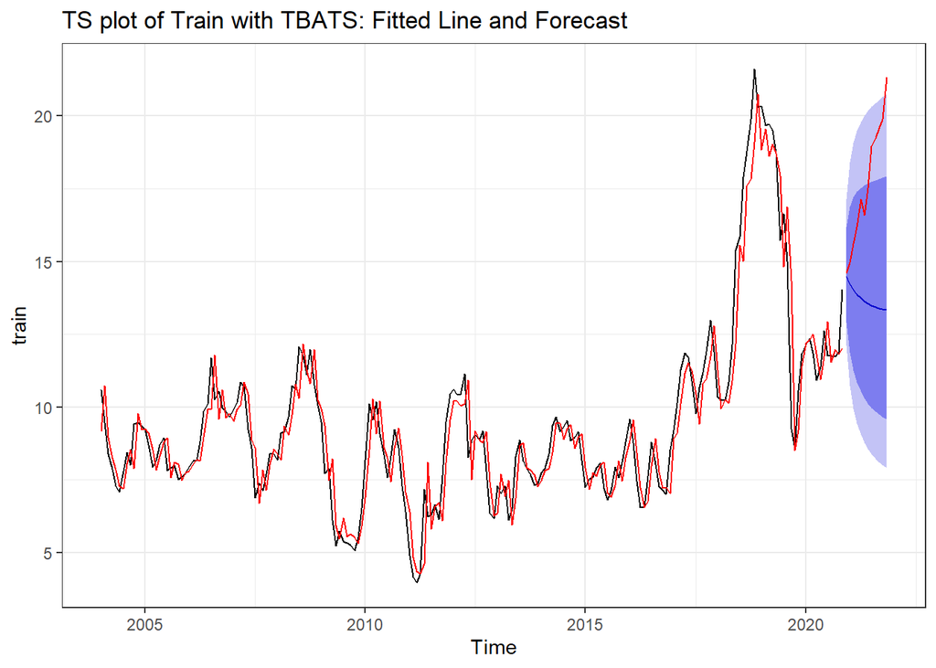

```r
tbatsmodel<-tbats(train)

tbats_forecast<-forecast(tbatsmodel, h = 12)

autoplot(train,main="TS plot of Train with TBATS: Fitted Line and Forecast") +
  autolayer(fitted(tbatsmodel), series="Fitted", color='red')+
  autolayer(tbats_forecast,series="actual",color="blue")+
  autolayer(test,series="actual",color="red") +
  scale_color_manual(labels = c("fitted line", "test"), values = c(3, 2)) +
  theme_bw()
```

Summary of TBATS model is located below:

```r
tbatsmodel
```

```
## BATS(0.342, {0,0}, 0.803, -)
##
## Call: tbats(y = train)
##
## Parameters
##   Lambda: 0.341606
##   Alpha: 1.367059
##   Beta: -0.2410842
##   Damping Parameter: 0.803098
##
## Seed States:
##             [,1]
## [1,]  3.34098163
## [2,] -0.03714475
## attr(,"lambda")
## [1] 0.3416063
##
## Sigma: 0.2202441
## AIC: 1065.517
```

**Checking The Performance of The TBATS Model**

```r
accuracy(tbats_forecast,test)
```

```
##                      ME      RMSE      MAE        MPE      MAPE     MASE
## Training set 0.08432927 0.9904553 0.725793 -0.1339823  7.899207 0.245259
## Test set     3.91840061 4.5871036 3.918401 20.9314282 20.931428 1.324101
##                    ACF1 Theil's U
## Training set 0.04354806        NA
## Test set     0.70892798  5.526178
```

**Checking The Normality of Residuals For TBATS**

As it is seen, residuals do not follow normal distribution for TBATS.

```r
shapiro.test(resid(tbatsmodel))
```

```
##
##  Shapiro-Wilk normality test
##
## data:  resid(tbatsmodel)
## W = 0.97411, p-value = 0.0008405
```

**e. Forecasting With NNETAR**

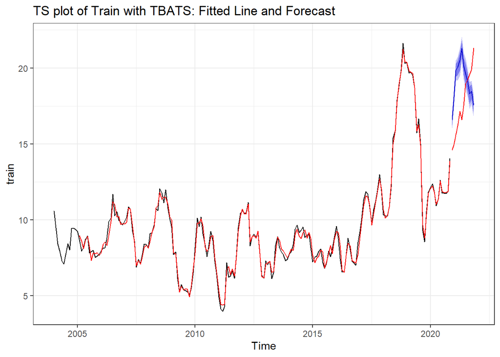

```r
nnmodel<-nnetar(train)

nnforecast<-forecast(nnmodel,h=12,PI=TRUE)

autoplot(train,main="TS plot of Train with TBATS: Fitted Line and Forecast") +
  autolayer(fitted(nnmodel), series="Fitted", color='red')+
  autolayer(nnforecast,series="actual",color="blue")+
  autolayer(test,series="actual",color="red") +
  scale_color_manual(labels = c("fitted line", "test"), values = c(3, 2)) +
  theme_bw()
```

Summary of NNETAR model is located below:

```r
nnmodel
```

```
## Series: train
## Model:  NNAR(13,1,7)[12]
## Call:   nnetar(y = train)
##
## Average of 20 networks, each of which is
## a 13-7-1 network with 106 weights
## options were - linear output units
##
## sigma^2 estimated as 0.08362
```

**Checking The Performance of The NNETAR Model**

```r
accuracy(nnforecast,test)
```

```
##                         ME      RMSE       MAE        MPE      MAPE       MASE
## Training set  0.0001304604 0.2891693 0.2215999 -0.2623093  2.593662 0.07488273
## Test set     -1.4920187861 2.9627880 2.6073019 -9.9632305 15.381465 0.88105597
##                    ACF1 Theil's U
## Training set 0.02982746        NA
## Test set     0.69284220  3.968995
```

**Checking The Normality of Residuals For NNETAR**

As it is seen, residuals follow normal distribution for NNETAR.

```r
shapiro.test(resid(nnforecast))
```

```
##
##  Shapiro-Wilk normality test
##
## data:  resid(nnforecast)
## W = 0.99091, p-value = 0.2751
```

**Comparing The Performance of All Models**

Below is `train accuracy`:

```r
#train
ac_train_nn <- accuracy(nnforecast,test)[1, 1:5]
ac_train_tbats <- accuracy(tbats_forecast,test)[1, 1:5]
ac_train_ets <- accuracy(ets4, test)[1, 1:5]
ac_train_prophet <- accuracy(tail(forecast$yhat, 203), train)[1, 1:5]

ac_train_nn <- as.data.frame(ac_train_nn)
ac_train_tbats <- as.data.frame(ac_train_tbats)
ac_train_ets <- as.data.frame(ac_train_ets)
ac_train_prophet <- as.data.frame(ac_train_prophet)

acf_nn <- accuracy(nnforecast,test)[1, 7]
acf_tbats <- accuracy(tbats_forecast,test)[1, 7]
acf_ets <- accuracy(ets4, test)[1, 7]
acf_prophet <- accuracy(tail(forecast$yhat, 203), train)[1, 6]

acf_nn <- as.data.frame(acf_nn)
acf_tbats <- as.data.frame(acf_tbats)
acf_ets <- as.data.frame(acf_ets)
acf_prophet <- as.data.frame(acf_prophet)

acfss_trains <- cbind(acf_nn, acf_tbats, acf_ets, acf_prophet)

colnames(acfss_trains) <- c('ac_train_nn', 'ac_train_tbats', 'ac_train_ets', 'ac_train_prophet')

#train accuracy
acfs_train <- cbind(ac_train_nn, ac_train_tbats, ac_train_ets, ac_train_prophet)

train_accuracy_last <- rbind(acfs_train, acfss_trains)

rownames(train_accuracy_last) <- c('ME', 'RMSE', 'MAE', 'MPE', 'MAPE', 'ACF1')

colnames(train_accuracy_last) <- c('NNETAR', 'TBATS', 'ETS', 'PROPHET')

train_accuracy_last['SARIMA'] <- NA

train_accuracy_last
```

```
##             NNETAR       TBATS          ETS    PROPHET SARIMA
## ME    0.0001304604  0.08432927  0.029634188 -0.3739569     NA
## RMSE  0.2891693457  0.99045529  0.996187357  2.4389797     NA
## MAE   0.2215998575  0.72579295  0.722973640  1.9071447     NA
## MPE  -0.2623092693 -0.13398230 -0.009532464 -9.4206321     NA
## MAPE  2.5936615510  7.89920674  7.975825229 21.1532643     NA
## ACF1  0.0298274602  0.04354806  0.106418980  0.9115675     NA
```

Below is `test accuracy`:

```r
#test
ac_test_nn <- accuracy(nnforecast,test)[2, 1:5]
ac_test_tbats <- accuracy(tbats_forecast,test)[2, 1:5]
ac_test_ets <- accuracy(ets4, test)[2, 1:5]
ac_test_prophet <- accuracy(tail(forecast$yhat, 12), test)[1, 1:5]

ac_test_nn <- as.data.frame(ac_test_nn)
ac_test_tbats <- as.data.frame(ac_test_tbats)
ac_test_ets <- as.data.frame(ac_test_ets)
ac_test_prophet <- as.data.frame(ac_test_prophet)

acf_nn_test <- accuracy(nnforecast,test)[2, 7]
acf_tbats_test <- accuracy(tbats_forecast,test)[2, 7]
acf_ets_test <- accuracy(ets4, test)[2, 7]
acf_prophet_test <- accuracy(tail(forecast$yhat, 12), test)[1, 6]

acf_nn_test <- as.data.frame(acf_nn_test)
acf_tbats_test <- as.data.frame(acf_tbats_test)
acf_ets_test <- as.data.frame(acf_ets_test)
acf_prophet_test <- as.data.frame(acf_prophet_test)

acfss_tests <- cbind(acf_nn_test, acf_tbats_test, acf_ets_test, acf_prophet_test)

colnames(acfss_tests) <- c('ac_test_nn', 'ac_test_tbats', 'ac_test_ets', 'ac_test_prophet')

#test accuracy
acfs_test <- cbind(ac_test_nn, ac_test_tbats, ac_test_ets, ac_test_prophet)

test_accuracy_last <- rbind(acfs_test, acfss_tests)

rownames(test_accuracy_last) <- c('ME', 'RMSE', 'MAE', 'MPE', 'MAPE', 'ACF1')

colnames(test_accuracy_last) <- c('NNETAR', 'TBATS', 'ETS', 'PROPHET')

test_accuracy_last['SARIMA'] <- accuracy(f_t,test_for_arıma)[, 1:6]

test_accuracy_last
```

```
##          NNETAR     TBATS        ETS    PROPHET     SARIMA
## ME   -1.4920188  3.918401  2.6799648  2.6672841  9.0952037
## RMSE  2.9627880  4.587104  3.2149615  3.2450062  9.3060719
## MAE   2.6073019  3.918401  2.6799648  2.6672841  9.0952037
## MPE  -9.9632305 20.931428 14.2339492 14.1027252 50.9903043
## MAPE 15.3814645 20.931428 14.2339492 14.1027252 50.9903043
## ACF1  0.6928422  0.708928  0.6933099  0.7216216  0.6140084
```

**SUMMARY OF ALL FORECASTS**

Plots from different models can be seen below.

**ARIMA**

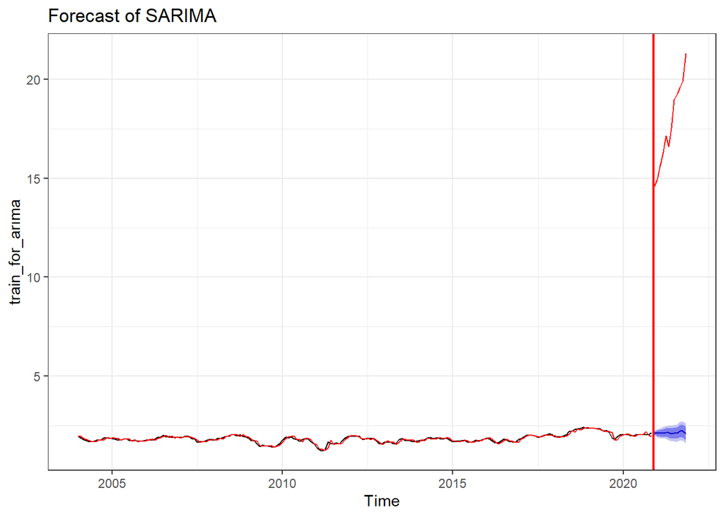

```r
#I don't know why but this code yields such an absurd graph when I knit. But I yield the graph in the word when I run this code in the normal script.
autoplot(f) +
  ggtitle("Forecast of SARIMA") +
  autolayer(fitted(f), series="Fitted", color='red') +
  autolayer(test, series="actual",color="red") +
  geom_vline(xintercept = 2020.9, color = "red", size=0.8) +
  theme_bw()
```

**ETS**

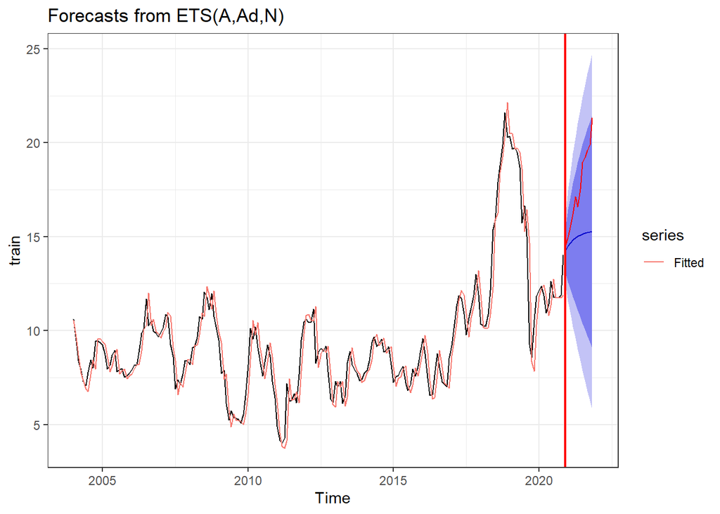

```r
a4 <- autoplot(ets4) +
      autolayer(fitted(ets4), series="Fitted") +
      autolayer(test,series="actual",color="red") +
      geom_vline(xintercept = 2020.9, color = "red", size=0.8) +
      theme_bw()
a4
```

**TBATS**

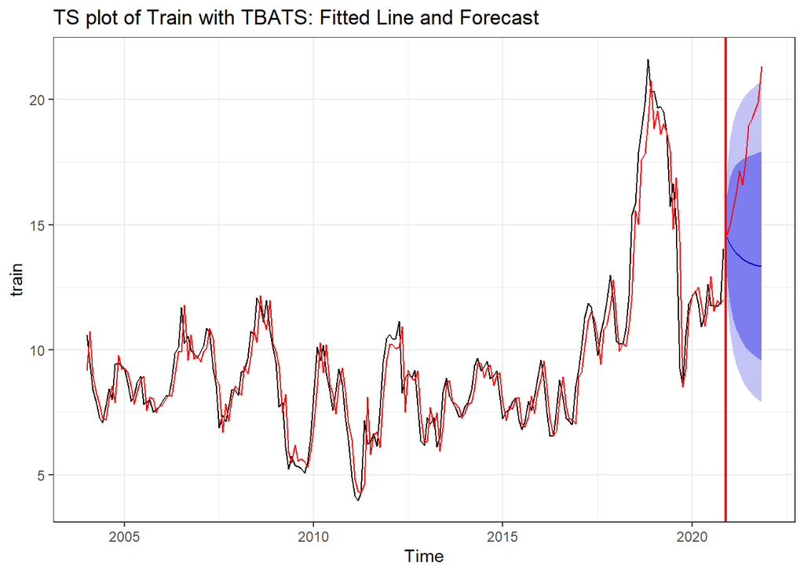

```r
autoplot(train,main="TS plot of Train with TBATS: Fitted Line and Forecast") +
  autolayer(fitted(tbatsmodel), series="Fitted", color='red')+
  autolayer(tbats_forecast,series="actual",color="blue")+
  autolayer(test,series="actual",color="red") +
  geom_vline(xintercept = 2020.9, color = "red", size=0.8) +
  theme_bw()
```

**NNETAR**

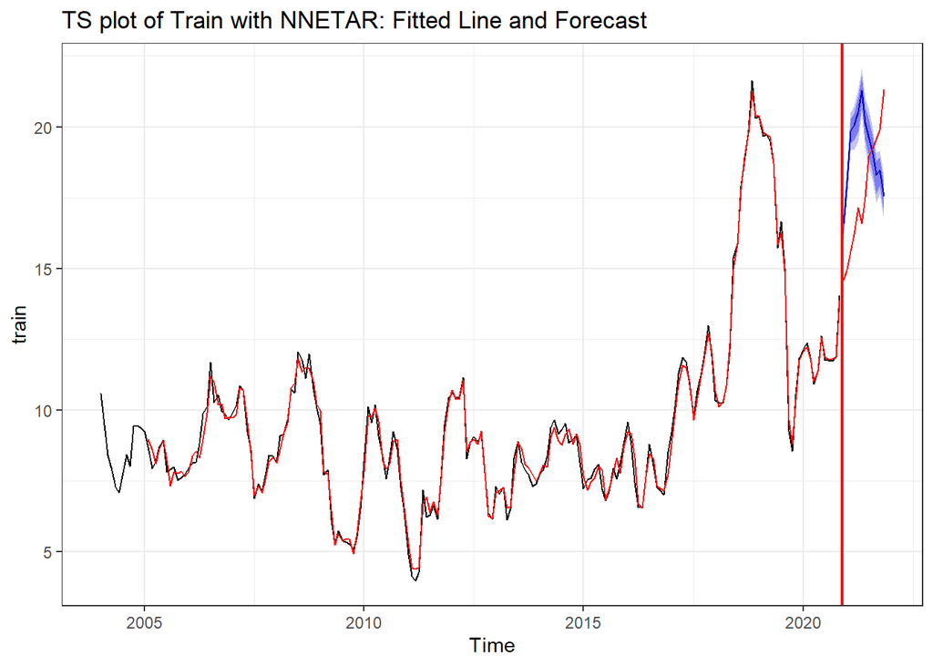

```r
autoplot(train,main="TS plot of Train with NNETAR: Fitted Line and Forecast") +
  autolayer(fitted(nnmodel), series="Fitted", color='red')+
  autolayer(nnforecast,series="actual",color="blue")+
  autolayer(test,series="actual",color="red") +
  geom_vline(xintercept = 2020.9, color = "red", size=0.8) +
  theme_bw()
```